# **Ejercicios 03 - Estadistica Computacional 13311**

John Serrano C.

2022-04-23

## **Problema 1: En el proceso de fabricación de teléfonos, tres de ellos son seleccionados aleatoriamente por trabajadores para evaluar su calidad. Cada pieza es categorizada como “funcional” o “con falla” según los resultados de su evaluación. Si la probabilidad de que un teléfono no tenga fallas es 0.8, siendo la evaluación independiente entre equipos.**

### **a) Señale el tipo de variable aleatoria y la distribución que sigue.**

Corresponde a una Variable numerica de tipo discreta, con una distribución binomial.

### **b) Determine la función de probabilidad de masa.**

Considerando la distribución binomial, podemos hacer un cálculo de las probabilidades, para obtener la función de probabilidad de masa, con x siendo la cantidad de exitos y n = 3, podemos obtener las probabilidades con x = {0,1,2,3}.

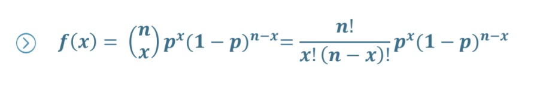

Formula Binomial

```r
telefonos = function(x){
  factorial(3)/(factorial(x)*factorial(3-x)) * 0.8^x * (1-0.8)^(3-x)
}
telefonos(0)
```

```
## [1] 0.008
```

```r
telefonos(1)
```

```
## [1] 0.096
```

```r
telefonos(2)
```

```
## [1] 0.384
```

```r
telefonos(3)
```

```
## [1] 0.512
```

Lo cual notemos que al sumar las probabilidades, obtenemos 1, lo cual cumple con las condiciones de la distribución binomial. Cualquier otro X da como probabilidad 0. Por lo tanto, la función de masa quedaria de la siguiente forma:

```r
x = c(0,1,2,3)
probabilidades = c(telefonos(0), telefonos(1), telefonos(2), telefonos(3))
datos = data.frame(x,probabilidades)
datos
```

```
##   x probabilidades
## 1 0          0.008
## 2 1          0.096
## 3 2          0.384
## 4 3          0.512
```

### **c) Grafique la distribución**

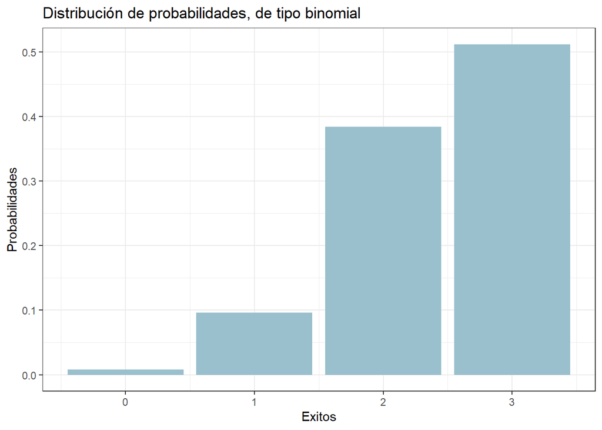

```r
library("ggplot2")
grafico = ggplot(data = datos, aes(x = x, y = probabilidades))
grafico = grafico + geom_bar(stat = "identity", fill = "lightblue3")
grafico = grafico + theme_bw() + ggtitle("Distribución de probabilidades, de tipo binomial")
grafico = grafico + xlab("Exitos") + ylab("Probabilidades")
plot(grafico)
```

## **Problema 2: En un estudio clínico los voluntarios son examinados para encontrar un gen asociado a la aparición de cáncer. La probabilidad de que una persona tenga el gen es 0.1. Si se asume que la evaluación de una persona es independiente de otra:**

### **a) Señale el tipo de variable aleatoria y la distribución que sigue.**

Corresponde a una variable numerica, de tipo discreta, con una distribución binomial negativa.

### **b) ¿Cuál es la probabilidad de que cuatro o más evaluaciones deban ser efectuadas para detectar a dos personas portadoras del gen?**

Considerando la formula de distribución binomail negativa, con r = 2:

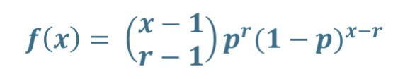

Formula binomial negativa

```r
# Utilizando pnbinom, podemos rapidamente calcular la distribucion
distribucion = (1-pnbinom(1,2,0.1))
distribucion
```

```
## [1] 0.972
```

### **c) ¿Cuál es el número esperado de evaluaciones que debo realizar para detectar dos personas portadoras del gen?**

En palabras simples, nos estan pidiendo la esperanza de la distribución binomial negativa, lo cual equivale a r/p, con r = 2 y p = 0.1

```r
esperanza = 2 / 0.1
esperanza
```

```
## [1] 20
```

### **d) Grafique la distribución.**

Considerando 10 personas:

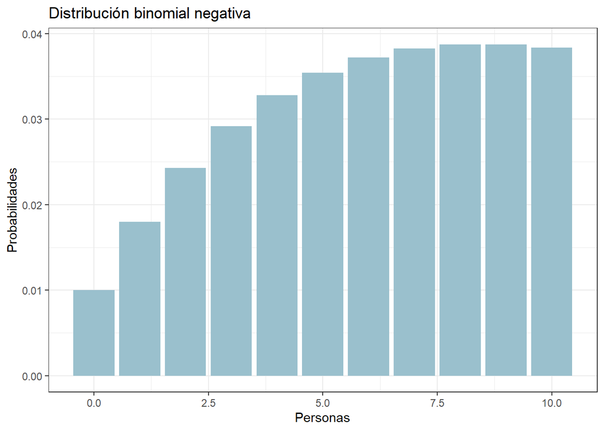

```r
personas = seq(0,10)
distribucion = dnbinom(personas, 2, prob=0.1)
datos=data.frame(personas,distribucion)

grafico = ggplot(data=datos,aes(x=personas,y=distribucion))
grafico = grafico + geom_bar(stat="identity",fill="lightblue3")
grafico = grafico + theme_bw() + ggtitle("Distribución binomial negativa")
grafico = grafico + xlab("Personas") + ylab("Probabilidades")
plot(grafico)
```

## **Problema 3: Una empresa contrata a 800 hombres menores de 55 años. Suponga que el 30 % tiene un marcador en el cromosoma masculino que indica un mayor riesgo de cáncer de próstata**

### **a) Señale el tipo de variable aleatoria y la distribución que sigue.**

Corresponde a una variable numerica, de tipo discreta, con una distribución Hipergeométrica

### **b) Si a 10 hombres de la empresa se les hace la prueba del marcador en este cromosoma, ¿cuál es la probabilidad de que exactamente 1 hombre tenga el marcador?**

Considerando que el 30% de los que tienen marcadir en el cromosoma masculino corresponden a 240 hombres, y que los hombres sanos son 560, podemos aplicar dhyper para rapidamente encontrar la distribución, considerando la formula de la distribución Hipergeométrica

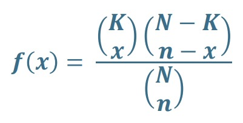

```r
distribucion = dhyper(x = 1, m = 240, k = 10, n = 560)
distribucion
```

```
## [1] 0.1200794
```

### **c) Si a 10 hombres de la empresa se les hace la prueba del marcador en este cromosoma, ¿cuál es la probabilidad de que más de 1 tenga el marcador?**

```r
distribucion = 1 - (dhyper(x = 1, m = 240, k = 10, n = 560)) - (dhyper(x = 0, m = 240, k = 10, n = 560))
distribucion
```

```
## [1] 0.8523523
```

### **d) Grafique la distribución**

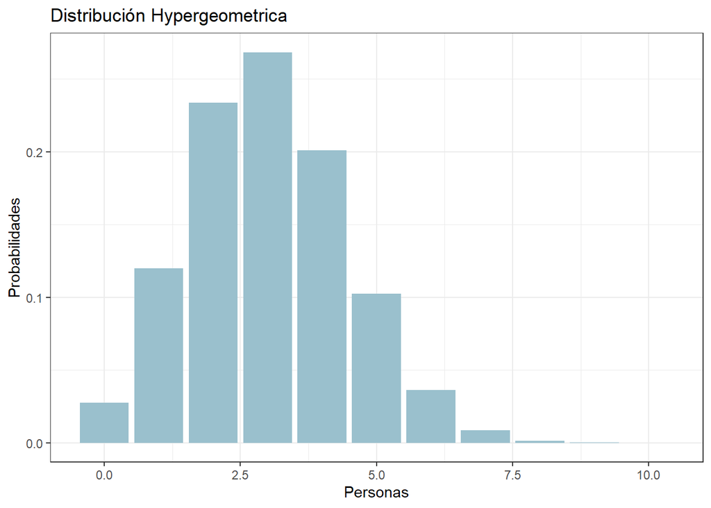

```r
personas = seq(0,10)
distribucion = dhyper(x = personas, m = 240, k =10, n = 560)
datos=data.frame(personas,distribucion)

grafico = ggplot(data=datos,aes(x=personas,y=distribucion))
grafico = grafico + geom_bar(stat="identity",fill="lightblue3")
grafico = grafico + theme_bw() + ggtitle("Distribución Hypergeometrica")
grafico = grafico + xlab("Personas") + ylab("Probabilidades")
plot(grafico)
```

## **Problema 4: El número de llamadas telefónicas que llegan a una central telefónica se modela como una variable aleatoria de Poisson. Suponga que en promedio hay 8 llamadas por hora.**

### **a) Señale el tipo de variable aleatoria y la distribución que sigue.**

Corresponde a una variable numerica, de tipo discreta, con una distribución de Poisson.

### **b) ¿Cuál es la probabilidad de que haya exactamente cinco llamadas en una hora?**

Considerando k = 5 y lambda = 8, podemos usar la función dpois() para facilmente calcular la distribución, considerando la formula de la distribución de Poisson:

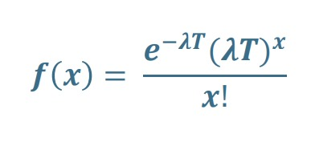

Distribución de Poisson

```r
distribucion = dpois(5,8)
distribucion
```

```
## [1] 0.09160366
```

### **c) ¿Cuál es la probabilidad de que haya tres llamadas o menos en una hora?**

Considerando ahora que k pertenecerá al intervalo [0,3], nuevamente podemos utilizar dpois()

```r
distribucion = dpois(0,8) + dpois(1,8) + dpois(2,8) + dpois(3,8)
distribucion
```

```
## [1] 0.04238011
```

## **Problema 6: Aborde los ejercicios 1 y 4 efectuando una aproximación mediante una distribución normal. ¿Qué puede concluir?**

### **Ejercicio 01:**

Debemos primero obtener la media y la desviacion, considerando los datos dados por el ejercicio 1

```r
media = 0.8 * 3
desviacion = sqrt((0.8 * 0.2 * 3))
distribucion = pnorm((3.5 - media) / desviacion)
distribucion
```

```
## [1] 0.9438244
```

Podemos calcular la inexactitud de la aproximación

```r
n = 3
p = 0.8
np = n*p
np
```

```
## [1] 2.4
```

```r
n*(1-p)
```

```
## [1] 0.6
```

Debido a que los valores son menores a 5, se concluye que no es una buena aproximación.

### **Ejercicio 04:**

### **Parte A:**

```r
x = (5-8) / sqrt(8)
distribucion = pnorm(x,0,1)
distribucion
```

```
## [1] 0.1444222
```

### ***Parte B:**

```r
x3 = (3-8) / sqrt(8)
x2 = (2-8) / sqrt(8)
x1 = (1-8) / sqrt(8)
x0 = (0-8) / sqrt(8)
distribucion = pnorm(x0,0,1) + pnorm(x1,0,1) + pnorm(x2,0,1) + pnorm(x3,0,1)
distribucion
```

```
## [1] 0.06450039
```

Como lambda es mayor a 5, se concluye que ambas aproximaciones no son buenas.